# Exploratory Analysis

## osu! RME Tournament Rating System

### Authors

Anh-Minh Nguyen (anhngu@uw.edu)

### Date

Spring 2024

### Abstract

Players of the online rhythm game osu! often question if the official ranking system accurately rates player skill. To explore this, we calculate a Rhythm Metrics Elo (RME) for every active tournament participant in osu! in the year 2023. We then analyze differences between the hierarchy of players in RME rating versus the official rankings.

### Keywords

Keywords: e-sports; ranking systems; glicko-2; skill-based rating

### Introduction

osu! is a rhythm game with about a million active users and a fairly large tournament community. In osu!, a player plays a “map”, a set of notes composed to the beat of a song. Upon completing the map, the player receives a numeric “score” that represents how well they played the map.

There is an official osu! performance rating system used to rank the skill level of all players. However, as many players notice, the official rating system does not encompass every skill that someone can master in osu!. Tournament play highlights these niche skillsets, offering more varied types of maps to test players on. Most of the best tournament players are indeed in the highest official ranks and vice versa, but some players stand out as especially skilled at either tournament play or singleplayer play.

Some questions I want to answer are:

- Who are the best tournament players?
- Are highly ranked players on the official leaderboards similarly highly ranked in tournament performance?
- Are highly performant players in tournaments similarly highly ranked in the official leaderboards?
- Is the official osu! ranking system representative of overall skill?

### Related Work

In this project I will compare scores set by players, but I will also simplify the analysis by only considering “wins”, “draws”, and “losses”, defined as achieving a higher, equal, or lower score as another player in the same match.

This simplification allows me to use ranking systems like Elo, used for zero-sum games like chess, tennis, and other e-sports (Ebtekar) (Moncav). In this project, I used the PlayerRatings package created by Alec Stephenson and Jeff Sonas, which includes a dynamic method for calculating Elo in variable-player games (Stephenson).

Ebtekar, A., & Liu, P. (2021). Elo-MMR: A rating system for massive multiplayer competitions. Proceedings of the Web Conference 2021. https://doi.org/10.1145/3442381.3450091

Glickman, M. E. (2022, March 22). Example of the glicko-2 system. http://www.glicko.net/glicko/glicko2.pdf

Moncav, M. (2020, March 6). What is elo? an explanation for competitive gaming’s Hidden Rating System. Dot Esports. https://dotesports.com/general/news/elo-ratings-explained-20565

Stephenson, A., & Sonas, J. (2020). PlayerRatings: Dynamic Updating Methods for Player Ratings Estimation. https://cran.r-project.org/package=PlayerRatings

### The Dataset

Where did you find the data? Please include a link to the data source Who collected the data?

I gathered my data by querying the osu! API ([link to documentation](https://osu.ppy.sh/docs/index.html)).

How was the data collected or generated?

To collect data on player scores, I first approximated the first and last tournament matches held in 2023. I found match IDs 105988619 and 111977659. Then, I queried the osu! API for every match ID in this range, added 20,000 IDs on either side, and filtered out various undesired data (see Limitations and Challenges). I then wrote each score to a .csv file.

Why was the data collected?

I collected this data for use in this project.

Explaining the datasets

There are two tables of data. The first, **Scores**, records scores set in tournament matches in the year 2023. The second, **Players**, records information about each player who appears in **Scores**, including their official rank, calculated RME rating, and country.

Data collection is about 60% complete. Currently, there are about 1,140,000 observations in the **Scores** dataset, and about 17,000 observations in the **Players** dataset. These encompass every osu! tourney match played from Jan 1, 2023 to August 13, 2023.

There are 8 features in the Scores dataset:

- Match ID - the ID number of the tournament match (integer)
- Tourney Abbreviation - a string representing the tourney this match was part of
- Datetime - when the map was played (expressed in UTC)
- Map ID - what map was played (integer)
- Player ID - who played this map (integer)
- Username - who played this map (string), accessed during data collection
- Mods - what ingame modifications the player had active during the map (enum)
- Score - what score the player achieved (integer from 0 to 1,250,000)

There are 6 features in the Players dataset:

- Player ID - a player’s ID
- Username - this player’s username
- Global rank - this player’s official rank (integer)
- Performance points - this player’s official performance score (float)
- RME Rating - this player’s RME rating (float)
- Location - the country displayed on this player’s profile (enum: ISO 3166-1 alpha-2 code)

Note that username, global rank, performance points, and location were accessed on May 18th, 04:00 UTC.

What, if any, ethical questions or questions of power do you need to consider when working with this data?

I might need to consider who has connections in the osu! tournament scene, allowing them to play in higher-skill tournaments.

What are possible limitations or problems with this data? (at least 200 words)

One limitation of this data is that I’ve currently only processed tournament matches up to Aug 13, 2023. A more extensive rating system would tally matches across several years, but I will only query the osu! API for one year’s worth of matches. A related limitation is that I accessed player data 5 months into 2024. Players will have gained or lost ranks in the 5 months since 2023, which will limit the conclusions I can make.

A problem that I mostly addressed is the fact that not all maps played in a tournament match are actually part of the match. Players will often play a “warm-up” map before the match, which is logged in the match history. Players can also play maps after the match is over, which is also logged in the match history. I cleaned most occurences of these by analyzing the amount of players who played each map.

Finally, I improperly used multiprocessing in my API scraper program, so a few dozen rows in my Scores dataset were corrupted by fellow scraper processes. I also forgot to filter out any non-osu!standard games. In the next phase of the project, I will requery every match ID after fixing these problems. For now, I have omitted these rows in my analysis.

### Implications

Finding discrepancies between players’ global ranks and tournament performance could inform the development team at osu! about what skillsets may be undervalued in the official rating system. A tournament rating system could also lead to new ways to categorize players by skill level: currently, most tournaments categorize players by Badge-Weighted Seeding (BWS), which uses a player’s official rank and the number of Badges they have (players earn Badges by winning officially supported tournaments). To some people, BWS is insufficient, because it is still tied to official rankings, places extreme emphasis on tournament winners, and doesn’t consider an individual player’s contribution to a winning team. A more tournament-based and individualized approach may be more accurate at estimating player skill.

### Limitations & Challenges

A fundamental limitation of applying an Elo model to osu! is that, in team-based tournaments, a player is free to not play a map. Only a subset of the team will play at any given time, so if a person doesn’t want to play a map, they can have their teammates fill in. This means that a player can almost always play to their strengths. A hypothetical player who always plays well on a single type of map and never plays any other map could theoretically top the rankings, despite most people valuing well-roundedness when talking about the “best” tournament players.

Data cleaning and preparation were the bulk of the work in this project. I filtered out these conditions while building my dataset:

- Matches that weren’t tournament matches
- Some maps which were not part of a match, e.g. warm-ups, tiebreaker showcases
- Matches which had zero maps played
- Maps which have been deleted from the osu! server

When calculating player ratings, I also filtered out these conditions:

- Maps played by only a single player
- Duplicated rows
- Malformed rows

I did not filter out these conditions:

- A few maps which were not part of a match, e.g warm-ups, because I could not algorithmically detect them
- Maps not played in the osu! standard gamemode, because I forgot to filter them. These will be filtered out when I re-gather data.

## Summary Information

We found that, from Jan 1 2023, to Aug 13 2023, “active” players (players who set at least 30 scores in the Scores dataset) achieved a mean RME rating of **1571.3**, and a median RME rating of **1548.2**. We define an “*n*-digit player” as a player with *n* digits in their global rank. For example, the 1,900<sup>th</sup> ranked player is a 4-digit player. Then, the phrase “*n*-digits” refers to every player with *n* digits in their global rank.

Across the ranks, there is a noticeable correlation between performance in the official rankings, and performance in tournaments. 6-digits have a mean RME of 1427.4, 5-digits have a mean RME of 1446.6, and 4-, 3-, 2-, and 1- digits have respective mean RMEs of 1722.7, 2037.1, 2390.4, and 2475. Higher-ranked players generally perform better in tournaments than lower-ranked players.

Higher-ranked players also play more tournaments on average. Of all active players, 6-digits played a mean of 87 maps, 5-digits played a mean of 141 maps, and 4-, 3-, 2-, and 1- digits played means of 177, 188, 271, and 283 maps respectively. This could mean that higher-ranked players are more motivated to play tournaments, or it could mean that players who play more tournaments become better players.

### Summary Table 1: Top 5 RME players

These are the top 5 highest-ranked players in the RME system, with their corresponding official ranks (as of May 17 2024):

| RMERanking | Username | RME | GlobalRank |
| --- | --- | --- | --- |
| 1 | worst hr player | 3211.179 | 35 |
| 2 | [Karcher] | 2940.543 | 42 |
| 3 | maliszewski | 2930.700 | 23 |
| 4 | mrekk | 2926.270 | 1 |
| 5 | hydrogen bomb | 2912.916 | 25 |

We can see that the best players in the RME system are also very highly-ranked in the offical system, including the official #1 osu! player, mrekk.

### Summary Table 2: Top 5 official players

These are the top 5 highest-ranked players in the offical system (as of May 17 2024), with their corresponding RME ranks:

| GlobalRank | Username | RMERanking | RME |
| --- | --- | --- | --- |
| 1 | mrekk | 4 | 2926.270 |
| 2 | Accolibed | 95 | 2476.817 |
| 3 | lifeline | 81 | 2493.137 |
| 4 | chud son | 1217 | 1898.417 |
| 5 | gnahus | 72 | 2527.982 |

We also see that the best players in the official ranking system are very highly-ranked in the RME system, with the exception of “chud son”, who is not a notable tournament player.

### Grouped Table: The most active countries

These are the 20 countries with the most active players from Jan 1 2023 to Aug 13 2023, along with each country’s highest-rated player:

| Location | Players | Average RME (2023) | Best Player (2023) | Best Player’s RME Ranking (2023) |
| --- | --- | --- | --- | --- |
| United States | 962 | 1571.9 | hydrogen bomb | 5 |
| Russian Federation | 490 | 1567.7 | Skrowell | 9 |
| Germany | 376 | 1564.9 | criller | 13 |
| Canada | 286 | 1620.3 | his kitten | 10 |
| France | 248 | 1572.1 | FlasTEH | 34 |
| China | 244 | 1643.2 | lolol233 | 12 |
| Poland | 242 | 1625.6 | maliszewski | 3 |
| Taiwan | 215 | 1556.8 | willy0214 | 33 |
| South Korea | 207 | 1659.1 | worst hr player | 1 |
| Vietnam | 207 | 1489.2 | Toshee | 304 |
| Indonesia | 197 | 1552.7 | Hakui Koyori | 76 |
| Brazil | 195 | 1523.1 | Dafonz | 115 |
| United Kingdom | 187 | 1582.4 | The Champion | 18 |
| Philippines | 168 | 1509.8 | enri | 6 |
| Australia | 152 | 1617.4 | mrekk | 4 |
| Singapore | 151 | 1549.2 | nvwrii | 16 |
| Malaysia | 131 | 1574.8 | Zeph2003 | 77 |
| Hong Kong | 116 | 1657.1 | mcy4 | 7 |
| Peru | 113 | 1495.1 | [MG]Arnold24x24 | 93 |
| Chile | 111 | 1591.7 | Intercambing | 25 |

I analyzed players grouped by country to see if geographic location had any impact on a player’s performance. We can see that, for all countries, their Average RME hovers within 100 points of the average RME of all active players (1571.3). Also, most countries have at least one player in the top 100 RME rankings. This suggests that geographic location has little impact on a player’s performance in tournaments.

### Chart 1a: Global Ranking VS RME Rating

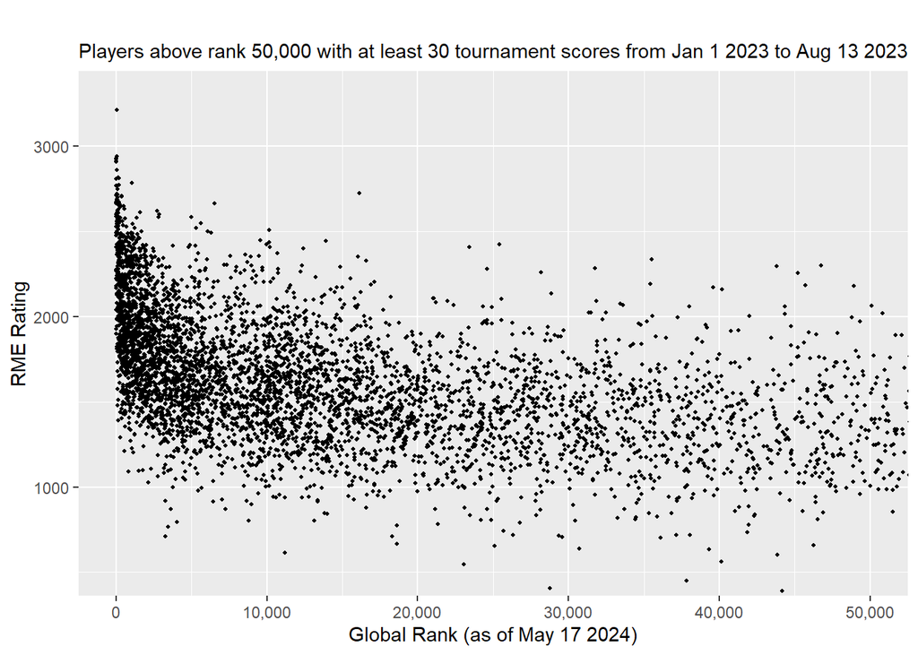

This scatterplot graphs a player’s official rank (as of May 17 2024) versus their RME rating, zoomed in on players in the top 50,000 global ranks.

### Chart 1b: Global Ranking (log) VS RME Rating

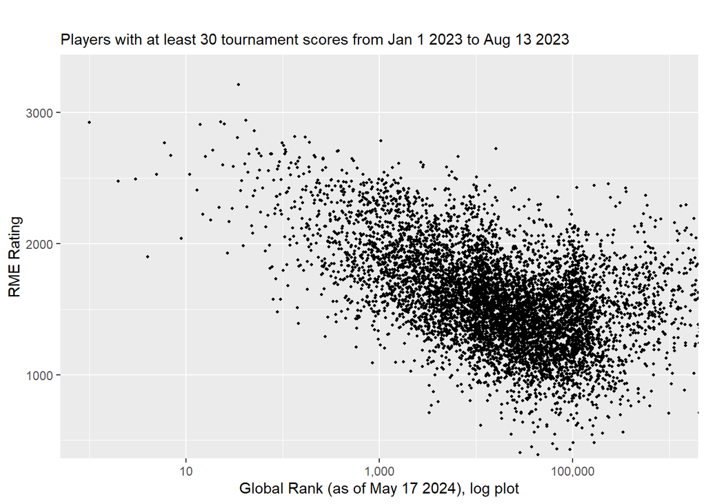

This scatterplot graphs the same data as Graph 1a, but using a log-plot for the Global Rank axis. I created this graph to see if the relationship between global rank and RME rating was logarithmic, which appears to be true. This matches up with my summary analysis, where I grouped players into *n*-digits, a base-10 logarithmic scale. There is a clear negative relationship between the log of a player’s global rank and their RME. This relationship breaks down for ranks beyond 100,000, but many of those players were calculated on gamemodes that aren’t osu!standard, which I forgot to filter out.

### Chart 2: Distribution of RME Ratings (up to Aug 13 2023)

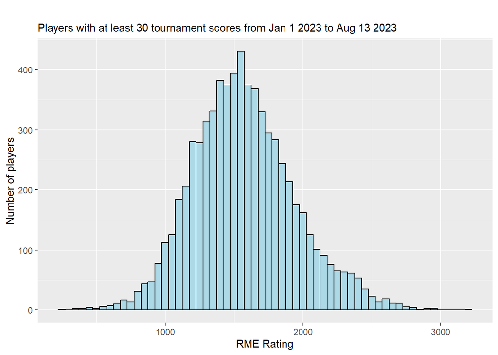

This histogram shows the distribution of players’ RME ratings, with a bin size of 50 RME.

I wanted to see if osu! tournaments were dominated by a small elite group of players, or if there’s a more balanced distribution of tournament performance. As noted in the summary, the mean RME rating is 1571.3. We can see that ratings are slightly skewed to the right, with a small group of players in the 2000-2400 range. This is not reflected on the other side of the mean, as there are very few players in the 600-1000 range. However, the vast majority of players are still within 500 RME of the mean. This suggests that the osu! tournament scene has a very balanced population between lower, middle, and higher-skilled players.